# Funcion-WSSC

Gonzalo Caceres

2024-08-10

Ejemplo Práctico: Análisis de Rendimientos de Acciones En este ejemplo, analizaremos los patrones de rendimiento de diferentes acciones a lo largo del tiempo. Usaremos la correlación para agrupar acciones que tienen patrones de movimiento similares.

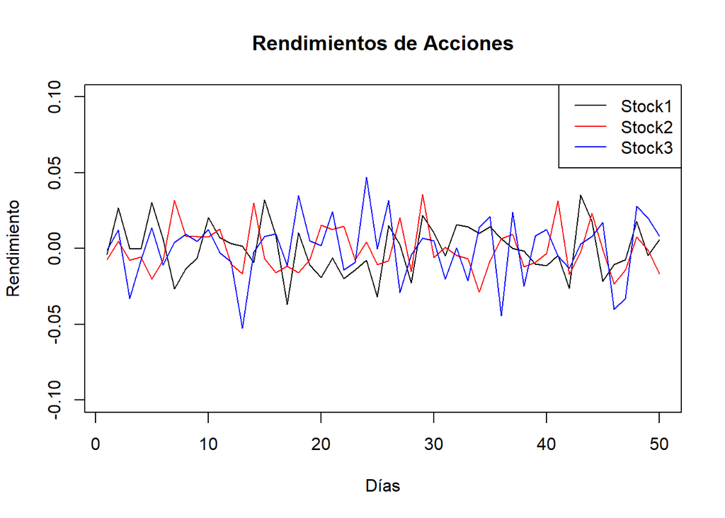

```r
# Generar datos de ejemplo
set.seed(123)
n_days <- 100
n_stocks <- 20

# Función para generar rendimientos correlacionados
generate_correlated_returns <- function(n, base_return, correlation) {
  base <- rnorm(n, mean = base_return, sd = 0.02)
  noise <- rnorm(n, mean = 0, sd = 0.02)
  return(base * correlation + noise * (1 - correlation))
}

# Generar rendimientos para 20 acciones
data <- matrix(0, nrow = n_days, ncol = n_stocks)
colnames(data) <- paste0("Stock", 1:n_stocks)

for (i in 1:n_stocks) {
  base_return <- runif(1, -0.001, 0.001)
  correlation <- runif(1, 0.5, 1)
  data[,i] <- generate_correlated_returns(n_days, base_return, correlation)
}

# Convertir a dataframe
data <- as.data.frame(data)

# Visualizar los primeros días de algunas acciones
plot(data$Stock1[1:50], type = "l", ylim = c(-0.1, 0.1),
     main = "Rendimientos de Acciones", xlab = "Días", ylab = "Rendimiento")
lines(data$Stock2[1:50], col = "red")
lines(data$Stock3[1:50], col = "blue")
legend("topright", legend = c("Stock1", "Stock2", "Stock3"),
       col = c("black", "red", "blue"), lty = 1)
```

```r
# Calcular la matriz de correlación
cor_matrix <- cor(data)

# Convertir correlaciones a distancias
dist_matrix <- as.dist(1 - cor_matrix)
```

Usamos la función wssc para calcular la suma de las distancias dentro de los clusters y generar la gráfica.

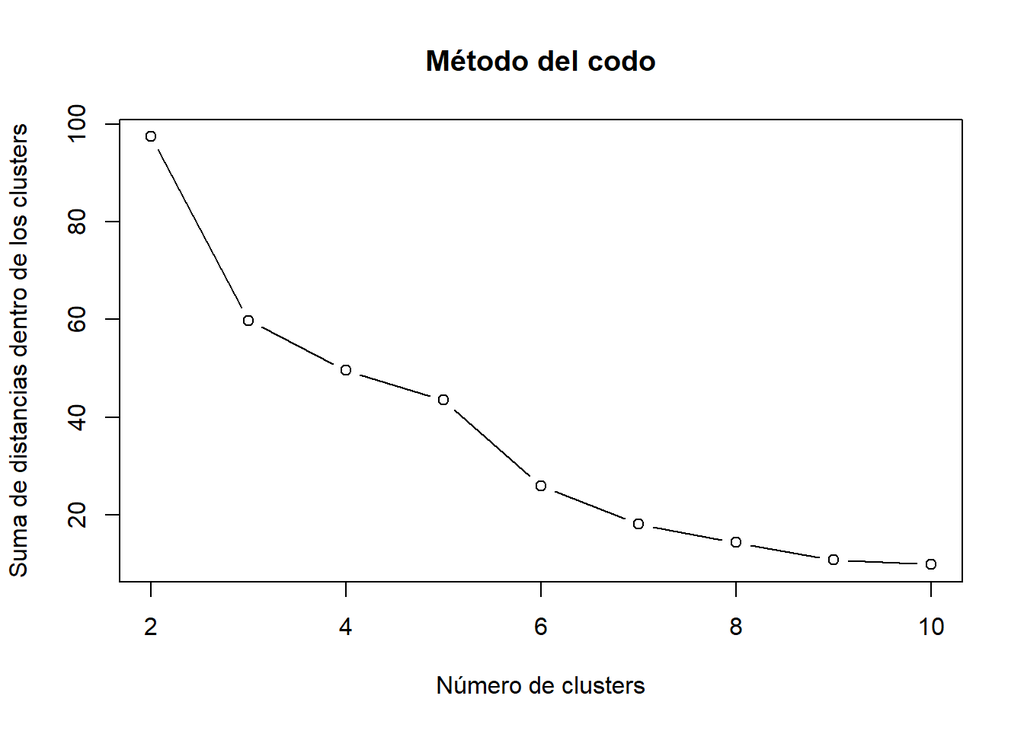

```r
# Definir la función wssc
wssc <- function(dist, num_k=10) {
  tree <- hclust(dist, method="complete")
  wss <- numeric(num_k)
  dist_matrix <- as.matrix(dist)

  for (k in 2:num_k) {
    clusters <- cutree(tree, k)
    wss[k] <- sum(sapply(unique(clusters), function(cluster) {
      cluster_points <- which(clusters == cluster)
      cluster_distances <- dist_matrix[cluster_points, cluster_points]
      sum(cluster_distances[upper.tri(cluster_distances)])
    }))
  }
  plot(2:num_k, wss[2:num_k], type="b", xlab="Número de clusters",
       ylab="Suma de distancias dentro de los clusters", main="Método del codo")
}

# Aplicar la función wssc
wssc(dist_matrix, num_k=10)
```

Interpretar los Resultados: Observamos la gráfica del método del codo para determinar el número óptimo de clusters. Buscamos el punto donde la disminución de la suma de distancias se estabiliza. Este punto sugiere el número óptimo de clusters.

Aplicar Clustering Jerárquico: Supongamos que la gráfica del codo sugiere que 4 es el número óptimo de clusters.

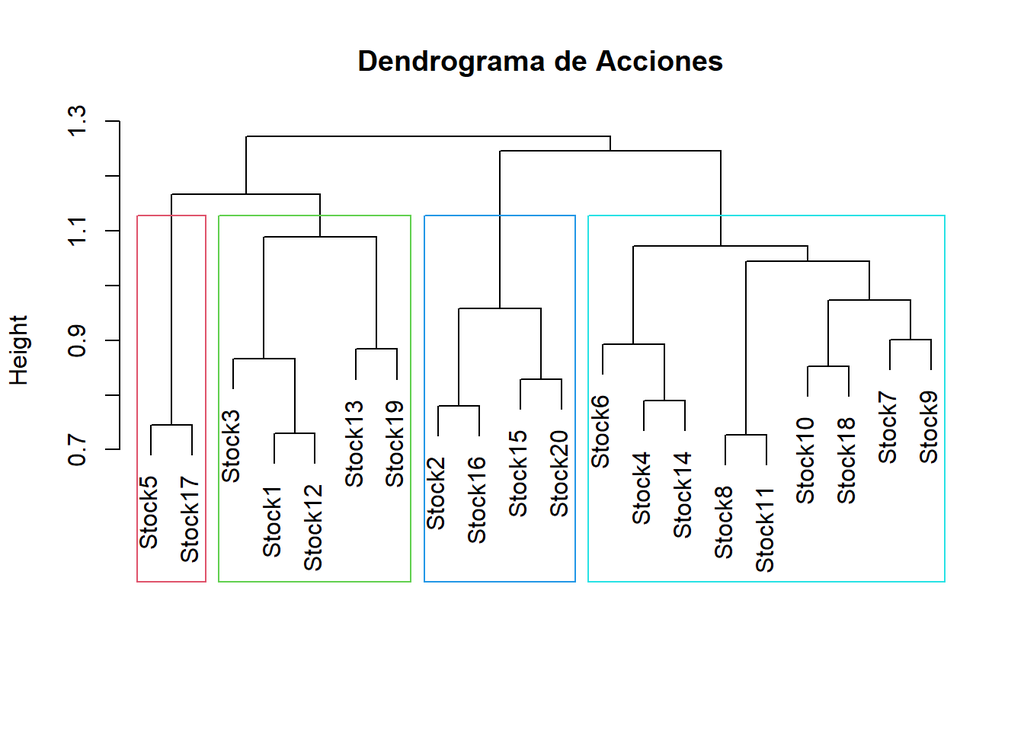

```r
# Realizar el clustering jerárquico con el número óptimo de clusters
optimal_clusters <- 4
tree <- hclust(dist_matrix, method="complete")
clusters <- cutree(tree, optimal_clusters)

# Visualizar el dendrograma
plot(tree, main = "Dendrograma de Acciones", xlab = "", sub = "")
rect.hclust(tree, k = optimal_clusters, border = 2:5)
```

```r
# Imprimir los clusters
for (i in 1:optimal_clusters) {
  cat("Cluster", i, ":", names(clusters[clusters == i]), "\n")
}
```

```
## Cluster 1 : Stock1 Stock3 Stock12 Stock13 Stock19
## Cluster 2 : Stock2 Stock15 Stock16 Stock20
## Cluster 3 : Stock4 Stock6 Stock7 Stock8 Stock9 Stock10 Stock11 Stock14 Stock18
## Cluster 4 : Stock5 Stock17
```

```r
# Calcular correlaciones promedio dentro de cada cluster
average_correlations <- sapply(1:optimal_clusters, function(i) {
  cluster_stocks <- names(clusters[clusters == i])
  mean(cor_matrix[cluster_stocks, cluster_stocks][lower.tri(diag(length(cluster_stocks)))])
})

print(data.frame(Cluster = 1:optimal_clusters,
                 Average_Correlation = average_correlations))
```

```
##   Cluster Average_Correlation
## 1       1          0.06387248
## 2       2          0.13485934
## 3       3          0.04862932
## 4       4          0.25446905
```

Interpretación

Uso de la Correlación: Al usar la correlación, estamos agrupando acciones basándonos en la similitud de sus patrones de movimiento, independientemente de la magnitud de sus rendimientos.

Método del Codo: La gráfica generada por wssc nos ayuda a identificar el número óptimo de clusters basándonos en cómo cambia la suma de distancias (basadas en correlación) dentro de los clusters.

Análisis de Correlaciones: Al examinar las correlaciones promedio dentro de cada cluster, podemos caracterizar qué tan fuertemente relacionadas están las acciones dentro de cada grupo.

Este ejemplo demuestra cómo la función wssc puede ser utilizada eficazmente con medidas de similitud basadas en correlación. Es particularmente útil en contextos financieros, donde los patrones de movimiento son a menudo más importantes que los valores absolutos. La flexibilidad de la función permite su aplicación en diversos contextos, adaptándose a diferentes tipos de datos y medidas de similitud o distancia.